```r
library(tidyverse)
NewSalary <- read.csv('/Users/tracy/Desktop/STAT5702_NYC_Employment_Analysis/DataPreprocessing/salary/NewSalary.csv')
NewSalary$Occupations <- as.factor(NewSalary$Occupations)
NewSalary$Gender <- as.factor(NewSalary$Gender)
NewSalary$Boroughs <- as.factor(NewSalary$Boroughs)
NewSalary$year <- as.factor(NewSalary$year)
NewSalary$year_range <- as.factor(NewSalary$year_range)
```

# Analyze on salary variation according to different years

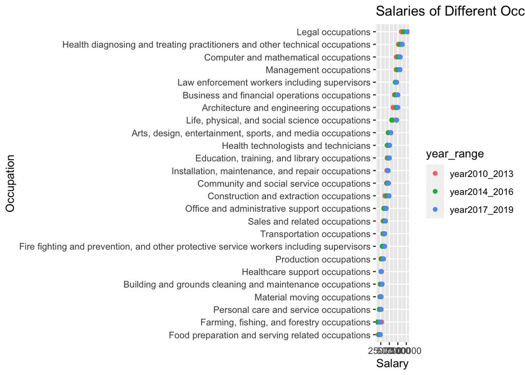

```r
ggplot(NewSalary) +
  geom_point(aes(Salary_year, reorder(Occupations,Salary_avg), color = year_range)) + ylab('Occupation') + xlab('Salary') +
  ggtitle('Salaries of Different Occupations of Different Times in NYC')
```

## Top 3 and Last 3 Occupations in Salary

### Top 3

1. Legal occupations This occupation is in an monotonous increasing trend in salary, and the increasing speed is also becoming faster.
2. Health diagnosing and treating practitioners and other technical occupations This occupation also has a monotonous increasing trend in salary.
3. Computer and mathematical occupations The salary variation trend of this group is similar to the previous two groups.

### Last 3

1. Food preparation and serving related occupations This occupation has the lowest salary within the year range between 2010 and 2013. However, its salary is in an increasing trend by years.
2. Farming, fishing, and forestry occupations The salary for this occupation decreased first and then increased. However, it did not reach the salary level to the year range from 2010 to 2013 even after increasing.
3. Personal care and service occupations The salary trend for this occupation also decreased first and then increased. Different from the occupation of farming, fishing, and forestry occupations, the salary only dropped a little bit first and then increased a lot. Therefore, generally speaking, the salary of this occupation increased.

## Different trends by years

Usually, we tend to think salaries should have increasing trends by years. From the plot, however, we can discover the salaries do not have an increasing trend for all types of occupations. Among all types of occupations, only two types of occupations have lower salaries in the year range from 2017 to 2019 than in the year range from 2010 to 2013, namely, farming, fishing and forestry occupations and healthcare support occupations. Generally speaking, there are two different trends of salaries, namely, a monotonous increasing trend, which includes 18 occupations, and the trend that first decreases then increases, which includes 7 occupations.

### Monotonous Increase

There are kinds of occupations in this trend group. 1. Legal occupations 2. Health diagnosing and treating practitioners and other technical occupations 3. Computer and mathematical occupations 4. Management occupations 5. Business and financial operations occupations 6. Architecture and engineering occupations 7. Arts, design, entertainment, sports, and media occupations 8. Education, training, and library occupations 9. Installation, maintenance, and repair occupations 10. Community and social service occupations 11. Construction and extraction occupations 12. Office and administrative support occupations 13. Sales and related occupations 14. Transportation occupations 15. Production occupations 16. Building and grounds cleaning and maintenance occupations 17. Material moving occupations 18. Food preparation and serving related occupations

### First Decrease Then Increase

1. Law enforcement workers including supervisors
2. Life, physical, and social science occupations
3. Health technologists and technicians
4. Fire fighting and prevention, and other protective service workers including supervisors
5. Healthcare support occupations
6. Personal care and service occupations
7. Farming, fishing, and forestry occupations

In this category, the salaries of some occupations decreased a lot and then increased a little, which makes these categories have a decreasing trend in general. However, for other occupations, the salaries decreased a little first and then increased a lot. For these occupations, they are in an increasing trend in general. To learn more about the exact changing trends of salaries in this group, we draw scatter plots to analyze the trends of these occupations in detail.

### Detailed Analysis on “First Decrease Then Increase” Occupations

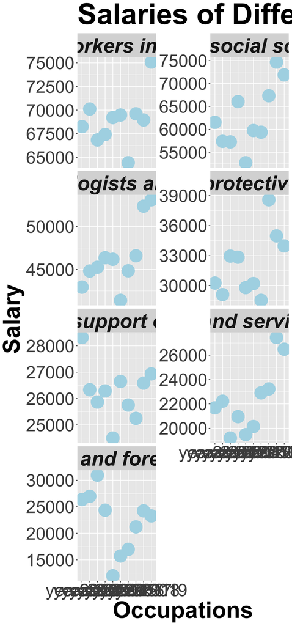

```r
NotMonotonous <- NewSalary[NewSalary$Occupations == "Law enforcement workers including supervisors" |
                                    NewSalary$Occupations == "Life, physical, and social science occupations"|
                                    NewSalary$Occupations == "Health technologists and technicians"|
                                    NewSalary$Occupations == "Fire fighting and prevention, and other protective service workers including supervisors"|
                                    NewSalary$Occupations == "Healthcare support occupations"|
                                    NewSalary$Occupations == "Personal care and service occupations"|
                                    NewSalary$Occupations == "Farming, fishing, and forestry occupations",]

NotMonotonous$year <- as.character(NotMonotonous$year)

NotMonotonous$Occupations <- factor(NotMonotonous$Occupations,levels = c("Law enforcement workers including supervisors",
                                                                         "Life, physical, and social science occupations",
                                                                         "Health technologists and technicians",
                                                                         "Fire fighting and prevention, and other protective service workers including supervisors",
                                                                         "Healthcare support occupations",
                                                                         "Personal care and service occupations",
                                                                         "Farming, fishing, and forestry occupations"))

ggplot(NotMonotonous,aes(year,Salary_YearlyAvg)) +
  geom_point(color = "light blue", size = 10) +
  facet_wrap(~Occupations,ncol=2,scales = "free_y") +
    theme(axis.text=element_text(size=30),
      axis.title=element_text(size=40,face="bold"),
        strip.text.x = element_text(
        size = 35, face = "bold.italic"
        ),
      strip.text.y = element_text(
        size = 35, color = "red", face = "bold.italic"
        ),
      plot.title = element_text(size = 50, face = "bold"))+
  ylab('Salary') + xlab('Occupations') + ggtitle('Salaries of Different Years by Occupations in NYC')
```

From the above plots, we see both the variations in salaries and the general trends for these occupations. 1. Law enforcement workers including supervisors For this occupation, the salary is in the trend of a wave. The crests are in year 2011, year 2015, and year 2019. The troughs are in year 2012 and year 2016. Besides, there are two special points for this occupation. a) The salary dropped a lot from 2015 to 2016, and then returned to normal quickly from 2016 to 2017. b) The salary was in an decreasing trend from 2017 to 2018, but it did not continue to decrease, instead, it increased a lot from year 2018 to 2019. 2. Life, physical, and social science occupations For this occupation, the salary is in also in the trend of a wave. At the same time, it is in an increasing trend in general. The crests are in year 2013 and 2018. The troughs are in year 2012 and 2014. 3. Health technologists and technicians From year 2010 to 2013, the salary of this occupation grew slightly at a steady rate. However, from 2014 to 2015, the salary had a sudden drop. After that, the salary started to increase at a higher rate. 4. Fire fighting and prevention, and other protective service workers including supervisors The salary of this group is in a waving trend and remains at a certain level in general. The crests are in 2012, 2013 and 2017, and the troughs are in 2011 and 2016. However, there is a special point for this occupation. a) The salary had a sudden increase from year 2016 to year 2017. 5. Healthcare support occupations Generally speaking, the salary trend is in a decreasing trend. The crests occurred in year 2010, 2013, and 2015. The troughs occured in year 2014 and 2017. 6. Personal care and service occupations Generally speaking, the salary of this occupation is in an increasing trend. It remained relatively stable before 2015, after that, the salary increased at a relatively high speed. 7. Farming, fishing, and forestry occupations For this occupation, it salary increased a little from 2011 to 2012, and then began to decrease at a high speed from 2012 to 2014. After that, the salary recovered at a lower but steady speed.

## Variance Percentages

It is also very important to analyze on the variations of salaries of different occupations. Because different occupations have different base wages, sometimes it might be more meaningful to calculate the percentage of wage fluctuations in wages. Here, we use the average wages to represent the wage of different occupations.

```r
# add variance to NewSalary
NewSalaryWithVariance <- NewSalary %>% select(1, 4, 11)
NewSalaryWithVariance <- unique(NewSalaryWithVariance)

NewSalaryWithVariance.wide <- pivot_wider(NewSalaryWithVariance, names_from = year, values_from = Salary_YearlyAvg)

NewSalaryWithVariance.wide$variance <- with(NewSalaryWithVariance.wide, year2019 - year2010)

NewSalaryWithVariance.tidy <- pivot_longer(NewSalaryWithVariance.wide, cols = c(2:11), names_to = "year", values_to = "Salary_YearlyAvg")

write.csv(NewSalaryWithVariance.tidy,"/Users/tracy/Desktop/STAT5702_NYC_Employment_Analysis/DataPreprocessing/Data/Preprocess_ClevelandDotPlot/NewSalaryWithVariance.csv", row.names = FALSE)
# draw cleveland dot plot according to variance

NewSalaryWithVariance <- read_csv("/Users/tracy/Desktop/STAT5702_NYC_Employment_Analysis/DataPreprocessing/Data/Preprocess_ClevelandDotPlot/NewSalaryWithVariance.csv")
```

```
##
## ─ Column specification ────────────────────────────
```

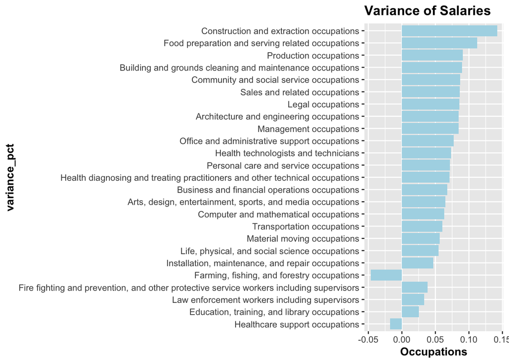

```r
NewSalaryWithVariance$year <- as.factor(NewSalaryWithVariance$year)
NewSalaryWithVariance$Occupations <- as.factor(NewSalaryWithVariance$Occupations)
NewSalaryWithVariance <- NewSalaryWithVariance %>%
  group_by(Occupations) %>%
  mutate(variance_pct = (variance/sum(Salary_YearlyAvg))/3)

ggplot(NewSalaryWithVariance,aes(x=fct_reorder(Occupations, abs(variance_pct)), y = variance_pct)) +
  geom_col(fill = "light blue")+
  coord_flip()+
    theme(axis.text=element_text(),
      axis.title=element_text(face="bold"),
      plot.title = element_text(face = "bold"))+ xlab('variance_pct') + ylab('Occupations') + ggtitle('Variance of Salaries')
```

As we can see from the above plot, we can discover that the majority of these occupations have positive variances in the past decade. Only two of these categories have negative variances. Among all occupations, the occupation of Construction and extraction occupations has the biggest variation in salary from 2010 to 2019, and the occupation of Healthcare support occupations has smallest variation in salary from 2010 to 2019.

## Boxplot

[figure not shown]

```r
ggplot(NewSalaryWithVariance) +
  geom_boxplot(aes(x = reorder(Occupations, -Salary_YearlyAvg, FUN = median), y = Salary_YearlyAvg),
               color = "black", fill = "dark red", alpha = 0.7) +
  ggtitle("Boxplots with Number of Employed for Different Occupations") +
  xlab("occupations")+
  theme(axis.text=element_text(size = 40, angle = 90, vjust = 0.5, hjust=1),
        axis.title=element_text(size=50,face="bold"),
        plot.title = element_text(size = 60, face = "bold"))
```

[output not shown]

# Analyze on salary difference according to different counties

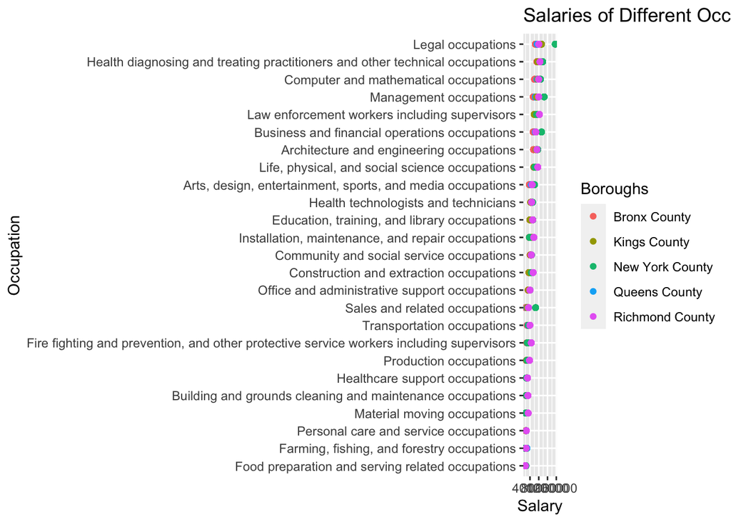

```r
ggplot(NewSalary) +
  geom_point(aes(Salary_county, reorder(Occupations,Salary_county), color = Boroughs)) + ylab('Occupation') + xlab('Salary') +
  ggtitle('Salaries of Different Occupations of Different Counties in NYC')
```

As can be seen in this plot, for different occupations, the counties with the highest and lowest wages in each occupation are different. For the majority of the occupations, the highest salaries are in New York County and their lowest salaries are in Bronx County. The detailed distribution is shown in the following table statistics.

| Boroughs | With the lowest wage | With the highest wage |
| --- | --- | --- |
| Bronx County | Legal occupations, Health diagnosing and treating practitioners and other technical occupations, Computer and mathematical occupations, Management occupations, Business and financial operations occupa… |  |
| Kings County | Law enforcement workers including supervisors |  |
| New York County | Healthcare support occupations, Material moving occupations, Farming, fishing, and forestry occupations | Legal occupations, Health diagnosing and treating practitioners and other technical occupations, Computer and mathematical occupations, Management occupations, Arts, design, entertainment, sports, and… |
| Queens County |  | Farming, fishing, and forestry occupations |
| Richmond County |  | Law enforcement workers including supervisors, Business and financial operations occupations, Architecture and engineering occupations, Life, physical, and social science occupations, Installation, ma… |

# Analyze on salary difference according to different genders

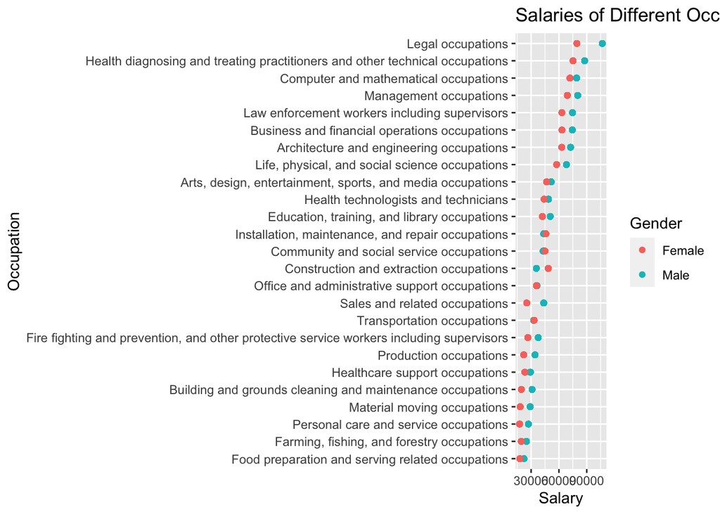

```r
ggplot(NewSalary) +
  geom_point(aes(Salary_gender, reorder(Occupations,Salary_gender), color = Gender)) + ylab('Occupation') + xlab('Salary') +
  ggtitle('Salaries of Different Occupations of Different Genders in NYC')
```